# Analysis of Variance Report 1

Melinda Higgins

October 21, 2016

## R Exercises - One-Way Analysis of Variance

The following exercise comes from [R Exercises at http://r-exercises.com/](http://r-exercises.com/), which is a site created by Research for Decisions, a Dutch research/consulting firm. They provide many exercises for learning R and practicing R coding skills. They also provide a large list of courses available for learning R - both free and paid - with detailed summaries of each option at http://r-exercises.com/r-courses/.

## Assumptions

When the data shows non-normality, unequal variance or presence of outliers, the data can be “transformed” *(such as square-root or log transformations to help skewness)* or a non-parametric test like Kruskal-Wallis can be used. It is good to note Kruskal-Wallis does not require normality of data but still requires equal variance in your groups. *[Note: There are transformation alternatives for handling unequal variances which will not be covered in this exercise.]*

## Load Data

For this exercise, the data come from patients having stomach, colon, ovary, brochus, or breast cancer. The objective of the study was to identify if the number of days a patient survived was influenced by the organ affected. Our dependent variable is Survival measured in days. Our independent variable is Organ.

The data is available at http://lib.stat.cmu.edu/DASL/Datafiles/CancerSurvival.html. The dataset we’re going to upload is the `cancer-survival.csv` file.

Since this dataset is a CSV (comma-delimited) formatted file, we can use the r function `read.csv()` to read in the dataset. This function returns a `data.frame` which we “assign” to the object `cancer.survival`.

Notice that the R chunk below is labeled “loaddata”. This will be apparent when we “knit” the final document. You’ll notice that there is a “chunk option” `eval=FALSE` indicating that this code will be shown in the document but the code is NOT executed yet.

```r
cancer.survival <- read.csv("cancer-survival.csv", header = TRUE)
```

This next code chunk is the same as above, but this time we have added a “chunk option” for the chunk to not be “echo’d” in the output, i.e. the R code will NOT be shown in the final document. To learn more about R chunk options see Yihui Xie’s website at http://yihui.name/knitr/options/. Yihui Xie’s book, “Dynamic Documents with R and knitr, Second Edition (Chapman & Hall/CRC The R Series) 2nd Edition”, is also very helpful in understanding how to customize and manipulate output using `knitr`. It is available at Amazon at https://www.amazon.com/dp/1498716962/ref=cm_sw_su_dp.

## Look at data

Let’s “look” at the data. We can use the `head()` function to look at the top 6 rows of the dataset or the `tail()` function to look at the bottom 6 rows of the dataset.

```r
head(cancer.survival)
```

```
##   Survival   Organ
## 1      124 Stomach
## 2       42 Stomach
## 3       25 Stomach
## 4       45 Stomach
## 5      412 Stomach
## 6       51 Stomach
```

```r
tail(cancer.survival)
```

```
##    Survival  Organ
## 59      727 Breast
## 60     3808 Breast
## 61      791 Breast
## 62     1804 Breast
## 63     3460 Breast
## 64      719 Breast
```

We can clean up the looks for this output by using the `kable()` function from the `knitr` package to put the output into a table.

```r
knitr::kable(head(cancer.survival))
```

| Survival | Organ |
| --- | --- |
| 124 | Stomach |
| 42 | Stomach |
| 25 | Stomach |
| 45 | Stomach |
| 412 | Stomach |
| 51 | Stomach |

The code again with a title/caption for the table.

```r
knitr::kable(head(cancer.survival),
             caption = "Table of the Top 6 Rows of Data")
```

Table of the Top 6 Rows of Data

| Survival | Organ |
| --- | --- |
| 124 | Stomach |
| 42 | Stomach |
| 25 | Stomach |
| 45 | Stomach |
| 412 | Stomach |
| 51 | Stomach |

We can also look at the “structure” of the data using the `str()` function.

```r
str(cancer.survival)
```

```
## 'data.frame':    64 obs. of  2 variables:
##  $ Survival: int  124 42 25 45 412 51 1112 46 103 876 ...
##  $ Organ   : Factor w/ 5 levels "Breast","Bronchus",..: 5 5 5 5 5 5 5 5 5 5 ...
```

## Select data and get stats

To select one of the columns in the dataset we can use the `$` selector to “select” by the variable name. You can see the column names using the `names()` function.

```r
names(cancer.survival)
```

```
## [1] "Survival" "Organ"
```

For example, we can find the mean survival time using the `mean()` function and selecting the 1st column which is `Survival` in the data frame `cancer.survival` using the followng code `mean(cancer.survival$Survival)`.

```r
mean(cancer.survival$Survival)
```

```
## [1] 558.625
```

Another way to select a data in a data frame is to use the row and column indices. To get the data element located at row 5 in column 1 we type `cancer.survival[5,1]`. The value should be 412.

```r
cancer.survival[5,1]
```

```
## [1] 412
```

To select a whole column, you leave the row index empty and enter the column number as `cancer.survival[,1]`. Let’s do a `summary()` of the 1st column of this dataset.

```r
summary(cancer.survival[,1])
```

```
##    Min. 1st Qu.  Median    Mean 3rd Qu.    Max.
##    20.0   102.5   265.5   558.6   721.0  3808.0
```

Since the 1st column `Survival` is a continuous variable, the `summary()` function gives us the min, max, median, 1st and 3rd quartiles. Let’s see what we get for the 2nd column, which is the list of Organs - it is a non-numeric text categorical variable.

```r
summary(cancer.survival[,2])
```

```
##   Breast Bronchus    Colon    Ovary  Stomach
##       11       17       17        6       13
```

We basically got the list of the Organs and the count (or frequency) of how many subjects survival times (i.e. number of data points) we have for each Organ. We can use the `summary()` command for the dataset as a whole and get the summary stats for both variables at the same time. If we use the `knitr::kable()` function around this summary, we get a nice summary stats table. Let’s also add a caption.

```r
knitr::kable(summary(cancer.survival),
             caption = "Table of Summary Statistics for 2 Variables in Dataset")
```

Table of Summary Statistics for 2 Variables in Dataset

|  | Survival | Organ |
| --- | --- | --- |
|  | Min. : 20.0 | Breast :11 |
|  | 1st Qu.: 102.5 | Bronchus:17 |
|  | Median : 265.5 | Colon :17 |
|  | Mean : 558.6 | Ovary : 6 |
|  | 3rd Qu.: 721.0 | Stomach :13 |
|  | Max. :3808.0 | NA |

## Clean up your code with “pipes” (`%>%`) - brief introduction to `dplyr` package

Our code is starting to get a little long, let’s learn how to use “pipes” in R with the `%>%` command. This is available from the `dplyr` package which utilizes this pipe command originally from the `magrittr` package. The idea behind this pipe command is that you place the commands in the order in which you use them. For example, to do the summary command above what we’re really doing is saying get the dataset `cancer.survival` and then run `summary()` on it. This code will do that. First we have to install and load the `dplyr` package.

```r
# install.packages("dplyr")
library(dplyr)
cancer.survival %>%
  summary()
```

```
##     Survival           Organ
##  Min.   :  20.0   Breast  :11
##  1st Qu.: 102.5   Bronchus:17
##  Median : 265.5   Colon   :17
##  Mean   : 558.6   Ovary   : 6
##  3rd Qu.: 721.0   Stomach :13
##  Max.   :3808.0
```

…and then to get that output into the `knitr::kable()` function, you simply add it as the next command in the sequence.

```r
cancer.survival %>%
  summary() %>%
  knitr::kable(caption = "Table of Summary Statistics for 2 Variables in Dataset")
```

Table of Summary Statistics for 2 Variables in Dataset

|  | Survival | Organ |
| --- | --- | --- |
|  | Min. : 20.0 | Breast :11 |
|  | 1st Qu.: 102.5 | Bronchus:17 |
|  | Median : 265.5 | Colon :17 |
|  | Mean : 558.6 | Ovary : 6 |
|  | 3rd Qu.: 721.0 | Stomach :13 |
|  | Max. :3808.0 | NA |

## Let’s try some inline code

Suppose I want to write a sentence providing the mean and standard deviation of the survival times seen across this dataset. We can use the functions `mean()` and `sd()` and use them “inline” - see example below.

The average survival time was 558.625 days with a standard deviation of 776.4786713 days.

Another way to do this is to assign the mean and standard deviation to objects and then just call those objects. This simplifies the inline code commands and can help in cleaning up your formatting. We can also use the `round()` function with the `digits=` option to set the number of digits to 1 or 2. Let’s create 2 objects one for the mean `mnsurv` and one for the standard deviation `sdsurv` and then use these to re-write the sentence. We’ll also use the `round()` function and set the number of digits (after the decimal place) to 2.

```r
mnsurv <- mean(cancer.survival$Survival)
sdsurv <- sd(cancer.survival$Survival)
```

The average survival time was 558.62 days with a standard deviation of 776.48 days.

## Let’s make a histogram of the survival times.

Using the `hist()` function, let’s make a histogram of the survival times overall and add a title.

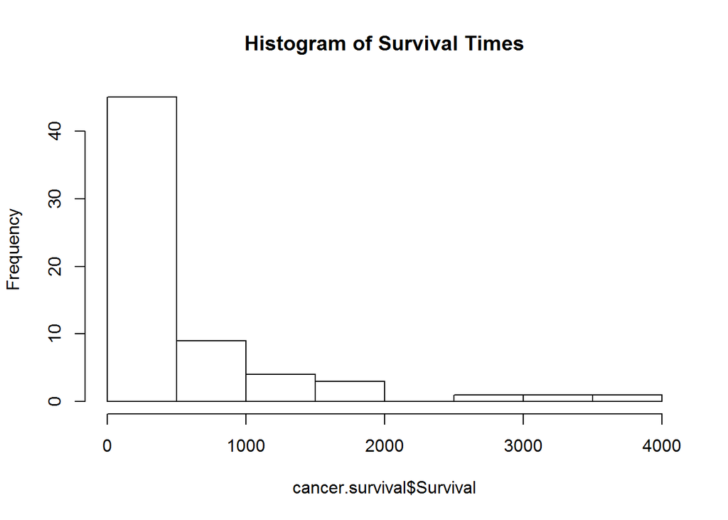

```r
hist(cancer.survival$Survival,
     main="Histogram of Survival Times")
```

We can also do this using the pipe command `%>%` and we’ll add include the title we used above. This time let’s add a Figure caption using a chunk option `fig.cap`. Learn more about `knitr` chunk options at http://yihui.name/knitr/options/.

NOTE: The `fig.cap` chunk option does show up in all outputs HTML, PDF and DOCX, but how these captions are displayed does vary.

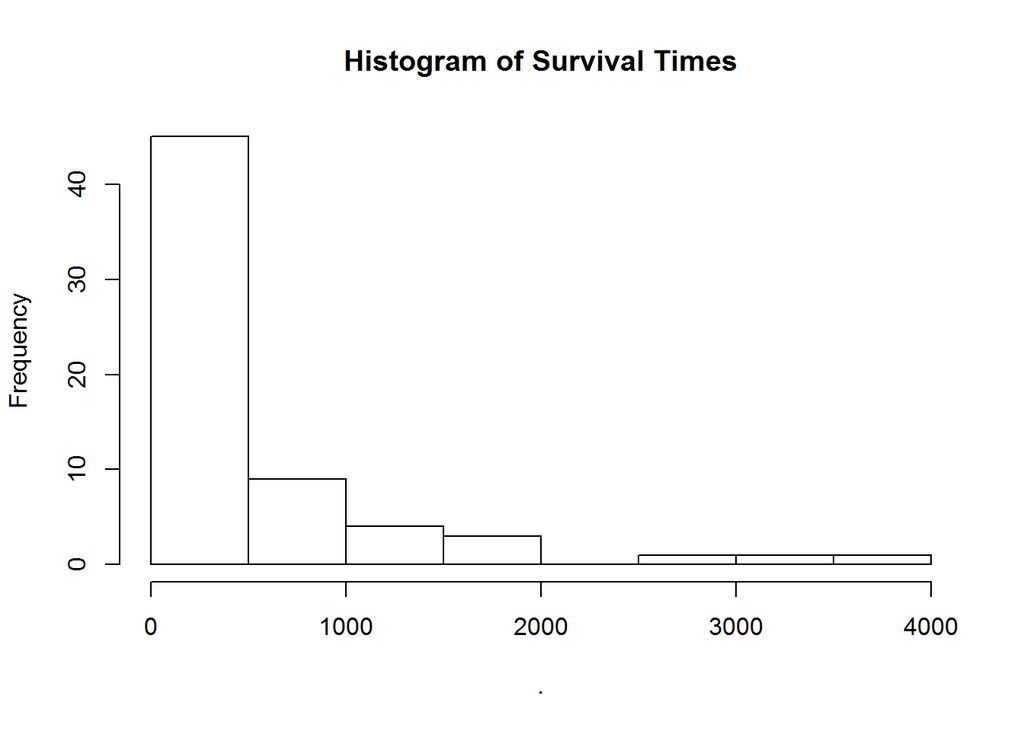

Figure: Histogram of Survival Times

```r
cancer.survival$Survival %>%
  hist(main="Histogram of Survival Times")
```

NOTE: In general, you may want to use the title and caption options within the table or plotting functions instead of using the chunk options. Although the chunk options can help automate captioning in larger documents - see Yihui Xie’s “Dynamic Documents” book for complete information.

## Make side-by-side boxplots of survival times by organ

For this plot we are going to use the `ggplot2` package and functions. So we have to install the package and load it.

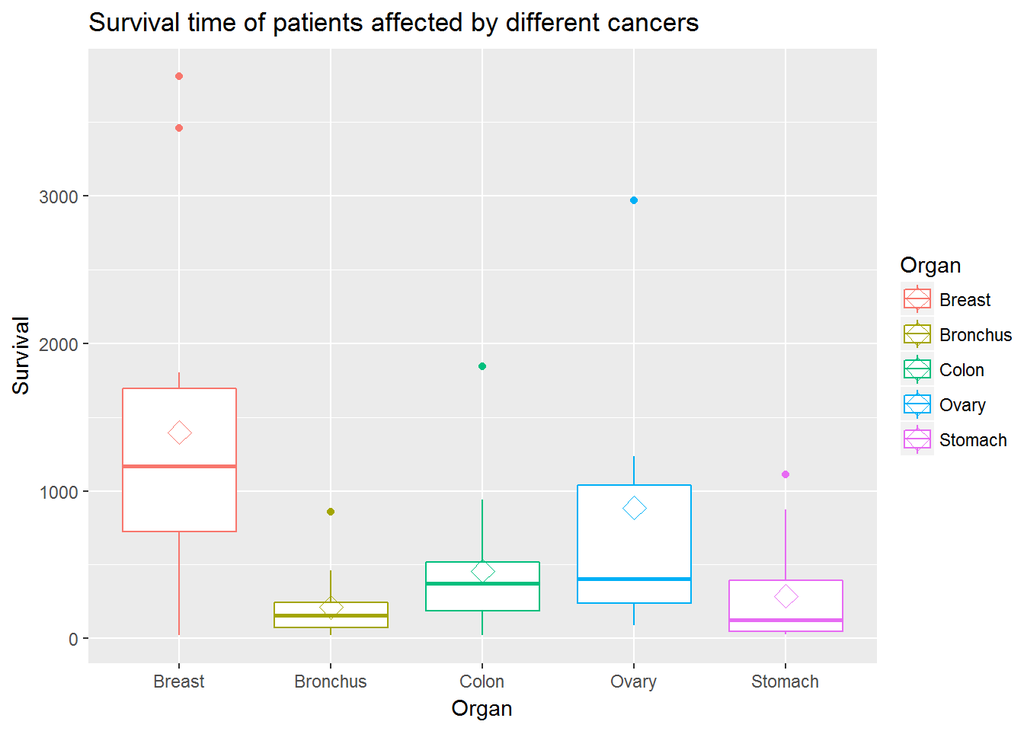

```r
# install.packages("ggplot2")
library(ggplot2)
ggplot(cancer.survival,
       aes(x = Organ,y=Survival, color = Organ)) +
  geom_boxplot() +
  stat_summary(fun.y=mean,
               geom="point",
               shape=23,
               size=4) +
  ggtitle("Survival time of patients affected by different cancers")
```

## Final Items to Do - Take Home Exercises

1. Go back and make sure that every R Code chunk has a label and make sure that every label is different. Try naming 2 chunks the same and see the error that is produced.
2. Go back and set the option `echo=FALSE` in all of your R code chunks so that all of your R code is hidden in the final document.
3. There are places in the above document where the same code was essentially run multiple times but with slightly different options. Find the duplicate chunks and set the evaluation option to false so the R code is not run `eval=FALSE`.
4. Add a Table of Contents for the HTML formatted output by editing the YAML header above. Change from

```
output:
  html_document: default
```

to

```
output:
  html_document:
    toc: true
```

5. If you’re feeling daring - try adding a theme to your HTML output - edit the YAML header as shown below. Read more about customizing HTML output at http://rmarkdown.rstudio.com/html_document_format.html. See the bootswatch themes at http://bootswatch.com/. NOTE: Not all of the bootswatch themes can be used - see `help(html_document)` for all of the details.

```
output:
  html_document:
    toc: true
    theme: "united"
```